# Multiway and Factorial ANOVA

Biol 607

For this lab, see the etherpad at https://etherpad.wikimedia.org/p/607-anova-2018

Let’s start with some libraries from last time!

```r
library(car)
library(tidyverse)
library(ggplot2)
library(emmeans)
```

## 1. Two-Way ANOVA

We’ll work with the zooplankton depredation dataset for two-way ANOVA. This is a blocked experiment, so, each treatment is in each block just once.

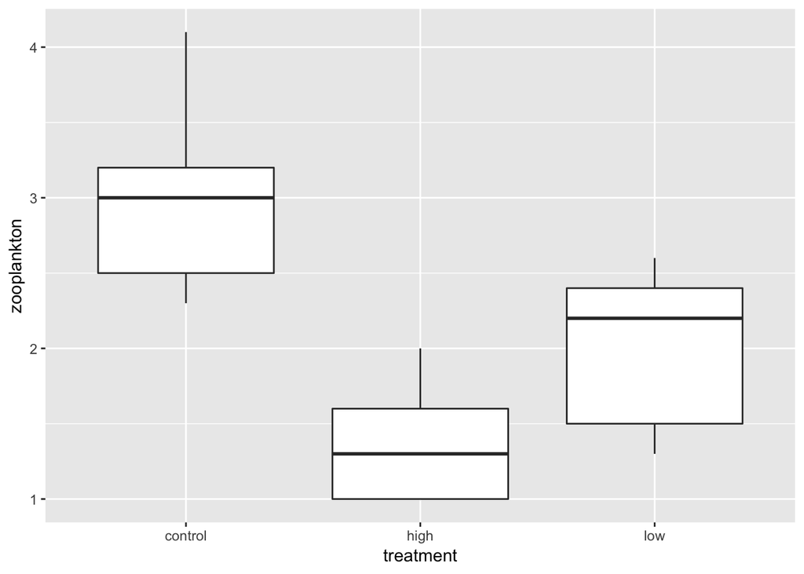

```r
zooplankton <- read.csv("./data/18e2ZooplanktonDepredation.csv")

qplot(treatment, zooplankton, data=zooplankton, geom="boxplot")
```

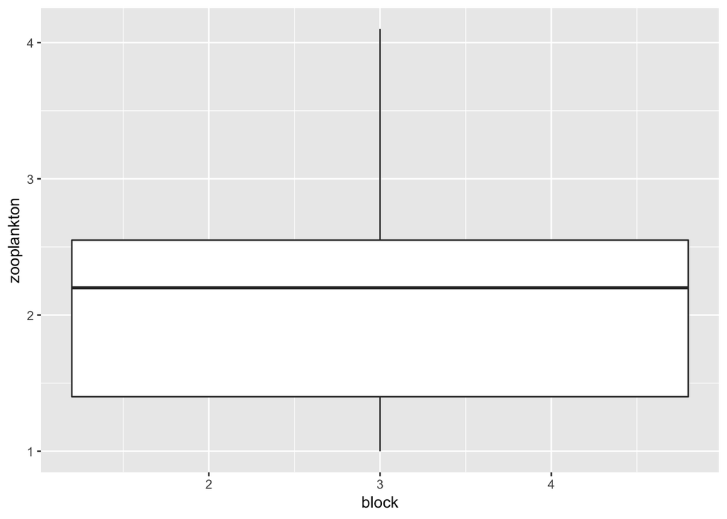

```r
qplot(block, zooplankton, data=zooplankton, geom="boxplot")
```

Oh. That’s odd. What is up with block? AH HA! It’s continuous. We need to make it discrete to work with it.

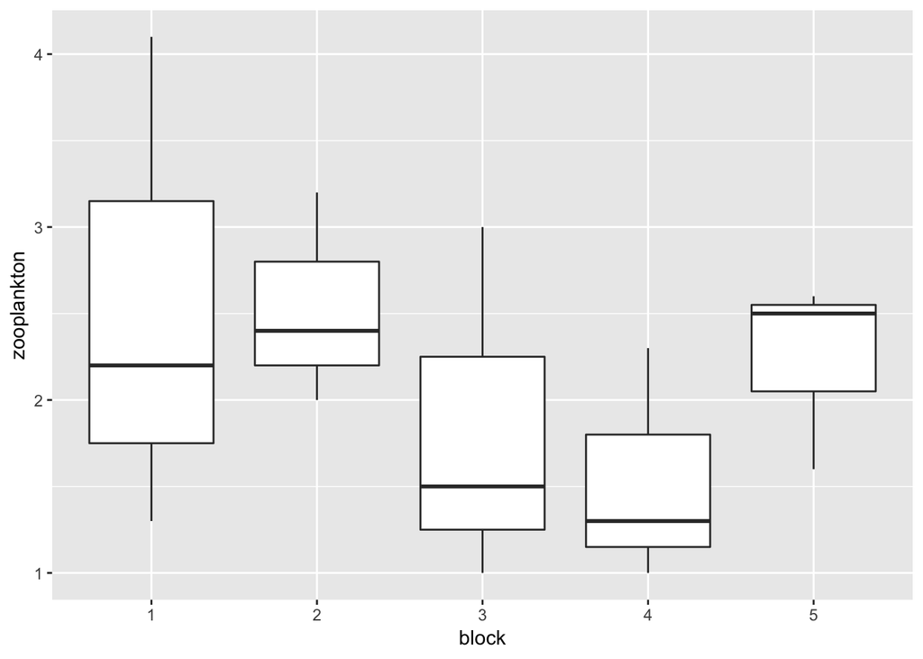

```r
zooplankton$block  <- factor(zooplankton$block)
qplot(block, zooplankton, data=zooplankton, geom="boxplot")
```

There we go. Always check!

### 1.1 Fit and Assumption Evaluation

Fit is quite easy. We just add one more factor to an lm model!

```r
zooplankton_lm <- lm(zooplankton ~ treatment + block,
                     data = zooplankton)
```

We then evaluate residuals almost as usual…

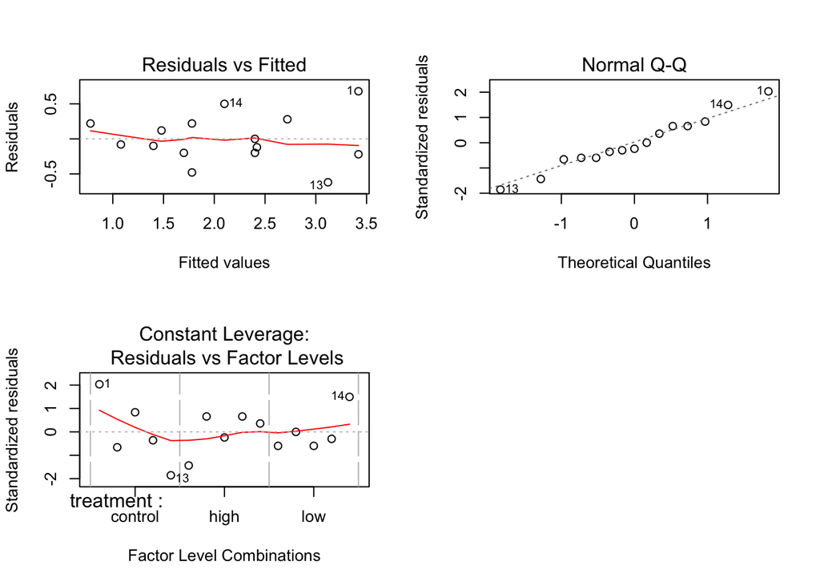

```r
par(mfrow=c(2,2))
plot(zooplankton_lm, which=c(1,2,5))
par(mfrow=c(1,1))
```

We want to look more deeply by treatment and block. For which we use `car`’s `residualPlots()`

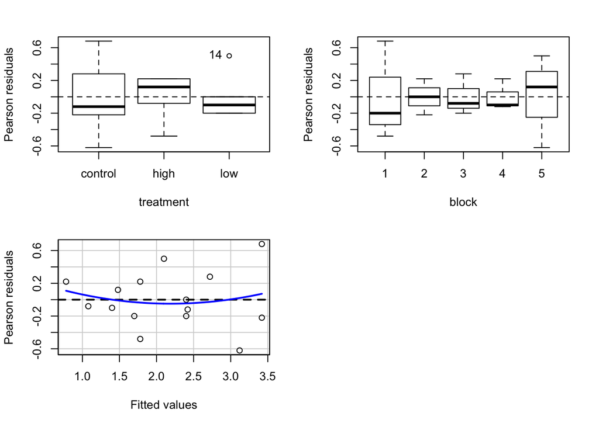

```
##            Test stat Pr(>|Test stat|)
## treatment
## block
## Tukey test    0.4742           0.6354
```

```r
residualPlots(zooplankton_lm)
```

Notice that this pops out a Tukey test, and we are looking…GOOD!

### 1.2 Type II Sums of Squares

Given that we now have multiple factors, in case of unbalance, we should use type II sums of squares.

```r
Anova(zooplankton_lm)
```

```
## Anova Table (Type II tests)
##
## Response: zooplankton
##           Sum Sq Df F value   Pr(>F)
## treatment 6.8573  2 16.3660 0.001488 **
## block     2.3400  4  2.7924 0.101031
## Residuals 1.6760  8
## ---
## Signif. codes:  0 '***' 0.001 '**' 0.01 '*' 0.05 '.' 0.1 ' ' 1
```

### 1.3 Coefficients

If we want to look at coefficients, we have to make means contrasts.

```r
summary(update(zooplankton_lm, . ~ . -1))
```

```
##
## Call:
## lm(formula = zooplankton ~ treatment + block - 1, data = zooplankton)
##
## Residuals:
##    Min     1Q Median     3Q    Max
##  -0.62  -0.20  -0.08   0.22   0.68
##
## Coefficients:
##                    Estimate Std. Error t value Pr(>|t|)
## treatmentcontrol  3.420e+00  3.127e-01  10.938 4.33e-06 ***
## treatmenthigh     1.780e+00  3.127e-01   5.693 0.000458 ***
## treatmentlow      2.400e+00  3.127e-01   7.676 5.88e-05 ***
## block2            7.166e-16  3.737e-01   0.000 1.000000
## block3           -7.000e-01  3.737e-01  -1.873 0.097945 .
## block4           -1.000e+00  3.737e-01  -2.676 0.028108 *
## block5           -3.000e-01  3.737e-01  -0.803 0.445316
## ---
## Signif. codes:  0 '***' 0.001 '**' 0.01 '*' 0.05 '.' 0.1 ' ' 1
##
## Residual standard error: 0.4577 on 8 degrees of freedom
## Multiple R-squared:  0.9788, Adjusted R-squared:  0.9603
## F-statistic: 52.82 on 7 and 8 DF,  p-value: 4.522e-06
```

This is still a little odd, though, as our treatments are evaluated in block 1. To truly get just the treatment effect, we need to look at the estimated marginal means - the `emmeans`! The big thing about `emmeans` is that it creates a reference grid based on the blocks. It then calculates the treatment effect averaged over all blocks, rather than just in block 1.

```r
zoop_em <- emmeans(zooplankton_lm, ~treatment)

zoop_em
```

```
##  treatment emmean        SE df  lower.CL upper.CL
##  control     3.02 0.2046949  8 2.5479727 3.492027
##  high        1.38 0.2046949  8 0.9079727 1.852027
##  low         2.00 0.2046949  8 1.5279727 2.472027
##
## Results are averaged over the levels of: block
## Confidence level used: 0.95
```

### 1.4 Post-Hocs

Here, `emmeans` gets interesting.

```r
contrast(zoop_em, method = "tukey")
```

```
##  contrast       estimate        SE df t.ratio p.value
##  control - high     1.64 0.2894823  8   5.665  0.0012
##  control - low      1.02 0.2894823  8   3.524  0.0190
##  high - low        -0.62 0.2894823  8  -2.142  0.1424
##
## Results are averaged over the levels of: block
## P value adjustment: tukey method for comparing a family of 3 estimates
```

Note the message that we’ve averaged over the levels of block. You can do any sort of posthoc as you wanted before. And, you could have done the same workflow for block as well.

### 1.5 Faded Examples

Given then similarity with 1-way ANOVA, let’s just jump right into two examples, noting a key difference or two here and there.

To start with, let’s look at gene expression by different types of bees.

```r
bees <- read.csv("./data/18q07BeeGeneExpression.csv")

#Visualize
________(type, Expression, data=____, geom="____")

#fit
bee_lm <- __(______ ~ ______ + _____, data=________)

#assumptions
________(______, which=c(1,2,4,5))

residualPlots(bee_lm)

#ANOVA
________(______)

#Tukey's HSD
contrast(________(______, ____, method = "________")
```

Wow, not that different, save adding one more term and the residualPlots.

OK, one more…. repeating an experiment in the intertidal?

```r
intertidal <- read.csv("./data/18e3IntertidalAlgae.csv")

#Visualize
________(herbivores, sqrtarea, data=____, geom="____")

#fit
intertidal_lm <- __(______ ~ ______ + _____, data=________)

#assumptions
________(______, which=c(1,2,4,5))

residualPlots(______)

#ANOVA
________(______)

#Tukey's HSD
contrast(________(______, ____, method = "________")
```

Did that last one pass the test of non-additivity?

## 2. Factorial ANOVA

Going with that last intertidal example, if you really looked, it was a factorial design, with multiple treatments and conditions.

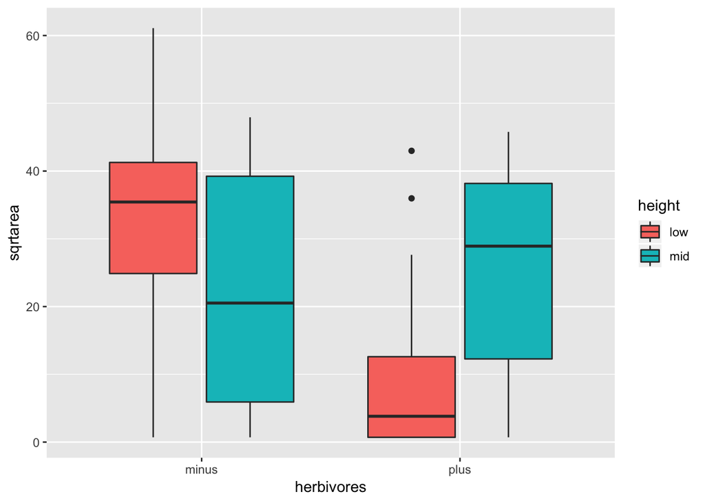

```r
qplot(herbivores, sqrtarea, data=intertidal, fill=height, geom="boxplot")
```

### 2.1 Fit and Assumption Evaluation

We fit factorial models using one of two different notations - both expand to the same thing

```r
intertidal_lm <- lm(sqrtarea ~ herbivores + height + herbivores:height, data=intertidal)

intertidal_lm <- lm(sqrtarea ~ herbivores*height, data=intertidal)
```

Both mean the same thing as `:` is the interaction. `*` just means, expand all the interactions.

But, after that’s done…all of the assumption tests are the same. Try them out.

### 2.2 Type II and III Sums of Squares

Now, we can choose type II or III SS once we have >n=1 for simple effects. Let’s see the difference. Both are from `Anova()` from the car package.

```r
Anova(intertidal_lm)
```

```
## Anova Table (Type II tests)
##
## Response: sqrtarea
##                    Sum Sq Df F value   Pr(>F)
## herbivores         1512.2  1  6.3579 0.014360 *
## height               89.0  1  0.3741 0.543096
## herbivores:height  2617.0  1 11.0029 0.001549 **
## Residuals         14270.5 60
## ---
## Signif. codes:  0 '***' 0.001 '**' 0.01 '*' 0.05 '.' 0.1 ' ' 1
```

```r
Anova(intertidal_lm, method="III")
```

```
## Anova Table (Type II tests)
##
## Response: sqrtarea
##                    Sum Sq Df F value   Pr(>F)
## herbivores         1512.2  1  6.3579 0.014360 *
## height               89.0  1  0.3741 0.543096
## herbivores:height  2617.0  1 11.0029 0.001549 **
## Residuals         14270.5 60
## ---
## Signif. codes:  0 '***' 0.001 '**' 0.01 '*' 0.05 '.' 0.1 ' ' 1
```

### 2.3 Post-Hocs

Post-hocs are a bit funnier. But not by much. As we have an interaction, let’s look at the simple effects. There are a few ways we can do this

```r
emmeans(intertidal_lm, ~ herbivores + height)
```

```
##  herbivores height   emmean       SE df  lower.CL upper.CL
##  minus      low    32.91450 3.855532 60 25.202290 40.62672
##  plus       low    10.40376 3.855532 60  2.691543 18.11597
##  minus      mid    22.48360 3.855532 60 14.771385 30.19581
##  plus       mid    25.55094 3.855532 60 17.838732 33.26316
##
## Confidence level used: 0.95
```

```r
emmeans(intertidal_lm, ~ herbivores | height)
```

```
## height = low:
##  herbivores   emmean       SE df  lower.CL upper.CL
##  minus      32.91450 3.855532 60 25.202290 40.62672
##  plus       10.40376 3.855532 60  2.691543 18.11597
##
## height = mid:
##  herbivores   emmean       SE df  lower.CL upper.CL
##  minus      22.48360 3.855532 60 14.771385 30.19581
##  plus       25.55094 3.855532 60 17.838732 33.26316
##
## Confidence level used: 0.95
```

```r
emmeans(intertidal_lm, ~ height | herbivores)
```

```
## herbivores = minus:
##  height   emmean       SE df  lower.CL upper.CL
##  low    32.91450 3.855532 60 25.202290 40.62672
##  mid    22.48360 3.855532 60 14.771385 30.19581
##
## herbivores = plus:
##  height   emmean       SE df  lower.CL upper.CL
##  low    10.40376 3.855532 60  2.691543 18.11597
##  mid    25.55094 3.855532 60 17.838732 33.26316
##
## Confidence level used: 0.95
```

Notice how each presents the information in a different way. The numbers are not different, they just show you information in different ways. The contrasts each reference grid implies *do* make s difference, though, in how p-value corrections for FWER is handled. Consider the first case.

```r
contrast(emmeans(intertidal_lm, ~ herbivores + height), method = "tukey")
```

```
##  contrast                estimate       SE df t.ratio p.value
##  minus,low - plus,low   22.510748 5.452546 60   4.128  0.0006
##  minus,low - minus,mid  10.430905 5.452546 60   1.913  0.2336
##  minus,low - plus,mid    7.363559 5.452546 60   1.350  0.5350
##  plus,low - minus,mid  -12.079843 5.452546 60  -2.215  0.1307
##  plus,low - plus,mid   -15.147189 5.452546 60  -2.778  0.0357
##  minus,mid - plus,mid   -3.067346 5.452546 60  -0.563  0.9427
##
## P value adjustment: tukey method for comparing a family of 4 estimates
```

OK, cool. Every comparison is made. But what if we don’t want to do that? What if we just want to see if the herbivore effect differs by height?

```r
contrast(emmeans(intertidal_lm, ~ herbivores |height), method = "tukey")
```

```
## height = low:
##  contrast      estimate       SE df t.ratio p.value
##  minus - plus 22.510748 5.452546 60   4.128  0.0001
##
## height = mid:
##  contrast      estimate       SE df t.ratio p.value
##  minus - plus -3.067346 5.452546 60  -0.563  0.5758
```

Notice that, because we’re only doing two contrasts, the correction is not as extreme. This method of contrasts might be more what you are interested in given your question. We can also see how this works visuall.

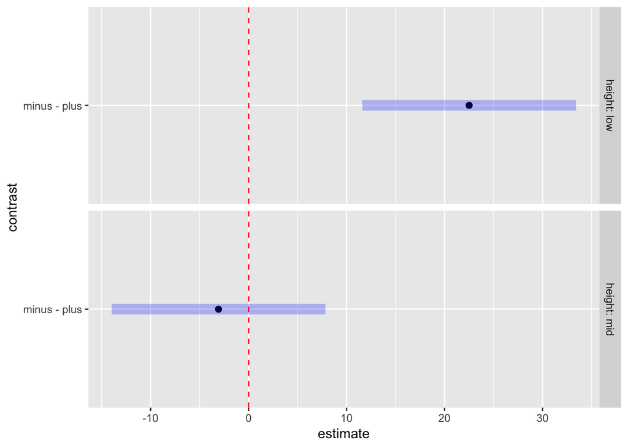

```r
cont <- contrast(emmeans(intertidal_lm, ~ herbivores |height), method = "tukey")

plot(cont) +
  geom_vline(xintercept = 0, color = "red", lty = 2)
```

You can then use `CLD` or your own annotations to complete the visualization

### 2.4 A Kelpy example

```r
kelp <- read.csv("./data/kelp_pred_div_byrnesetal2006.csv")

## Check and correct for non-factors
____________
_________

#Visualize
________(Treatment, Porp_Change, data=____, geom="____", fill=Trial)

#fit
kelp_lm <- __(______ ~ ______ * _____, data=________)

#assumptions
________(______, which=c(1,2,4,5))

residualPlots(_________)

#ANOVA
________(______)

#Tukey's HSD for simple effects
contrast(________(______, ____, method = "________")
```

#### 3.3.1 The Cost of Tukey

So, the kelp example is an interesting one, as this standard workflow is *not* what I wanted when I ran this experiment. I was not interested in a Tukey test of all possible treatments. Run it with no adjustement - what do you see?

```r
#Pariwise Comparison without P-Value adjustment - The LSD test
contrast(________(______, ____, method = "________", adjust = "_______")
```

Instead, I was interested in asking whether predator diversity - having a mixture versus only one species of predator - led to less kelp loss than any of the other treatments. There are a few ways to assess the answer to that question.

First, a Dunnet’s test with the Predator Mixture as the control. Try that out. Note, the default “control” is Dungeness crabs, so, you might want to revisit that.

```r
#Dunnet's Test
contrast(________(______, ____, method = "________", ref = _____)
```

What did you learn?

#### 3.3.2 Replicated Regression

So…. this was actually a replicated regression design. There are a few ways to deal with this. Note the column `Predator_Diversity`

Try this whole thing as a regression. What do you see?

Make a new column that is `Predator_Diversity` as a factor. Refit the factorial ANOVA with this as your treatment. NOW try a Tukey test. What do you see?

#### 3.3.3 A Priori Contrast F tests

OK, one more way to look at this. What we’re actually asking in comparing monocultures and polycultures is, do we explain more variation with a monoculture v. poyculture split than if not?

```r
kelp_contr <- lm(Change_g ~ C(factor(Predator_Diversity), c(0,1,-1))*Trial, data=kelp)

Anova(kelp_contr)
```

```
## Anova Table (Type II tests)
##
## Response: Change_g
##                                                  Sum Sq Df F value
## C(factor(Predator_Diversity), c(0, 1, -1))        87424  2  5.0689
## Trial                                            109084  1 12.6494
## C(factor(Predator_Diversity), c(0, 1, -1)):Trial   4440  2  0.2574
## Residuals                                        353570 41
##                                                     Pr(>F)
## C(factor(Predator_Diversity), c(0, 1, -1))       0.0107863 *
## Trial                                            0.0009646 ***
## C(factor(Predator_Diversity), c(0, 1, -1)):Trial 0.7742620
## Residuals
## ---
## Signif. codes:  0 '***' 0.001 '**' 0.01 '*' 0.05 '.' 0.1 ' ' 1
```

Now we see that, yes, we explain variation when we partition things into monoculture versus polyculture than when we do not.

Setting up a priori ways of partitioning your sums of squares (that must be orthogonal) is a powerful way to test grouping hypotheses and worth keeping in your back pocket for future explorations.